# Stats_506_PS3

Author

Annie Yannan Niu

## Github Link

https://github.com/nynn7747/Stats_506_PS3

## Problem 1

### a. Import data and merge as one dataframe

```r
library(haven)
# Use read_xpt to import SAS data into R
VIX <- read_xpt(
  "/Users/nynn/Library/CloudStorage/OneDrive-Umich/Umich course/2024_Fall/Stats 506/Stats_506_PS3/Stats_506_PS3/VIX_D.xpt",
  col_select = NULL,
  skip = 0,
  n_max = Inf,
  .name_repair = "unique"
)
DEMO <- read_xpt(
  "/Users/nynn/Library/CloudStorage/OneDrive-Umich/Umich course/2024_Fall/Stats 506/Stats_506_PS3/Stats_506_PS3/DEMO_D.xpt",
  col_select = NULL,
  skip = 0,
  n_max = Inf,
  .name_repair = "unique"
)

head(VIX)
```

```
# A tibble: 6 × 57
   SEQN VIQ110 VIQ121 VIQ130 VIQ141 VIQ150 VIQ160 VIQ170 VIXNC1 VIXNC2 VIQ180
  <dbl>  <dbl>  <dbl>  <dbl>  <dbl>  <dbl>  <dbl>  <dbl>  <dbl>  <dbl>  <dbl>
1 31129      2     NA      2     NA     NA     NA     NA     NA     NA      2
2 31130     NA     NA     NA     NA     NA     NA     NA     NA     NA     NA
3 31131      2     NA      2     NA     NA     NA     NA     NA     NA      2
4 31132      2     NA      2     NA      1      1      1      5     14      2
5 31133      2     NA      2     NA     NA     NA     NA     NA     NA      2
6 31134      2     NA      2     NA      1      1      1      5     15      2
# ℹ 46 more variables: VIQ191 <dbl>, VIQ200 <dbl>, VIQ211 <dbl>, VIQ220 <dbl>,
#   VIQ230 <dbl>, VIQ240 <dbl>, VIQ250 <dbl>, VIXPRS <dbl>, VIXPRC <dbl>,
#   VIXPRA <dbl>, VIXPLS <dbl>, VIXPLC <dbl>, VIXPLA <dbl>, VIXOCMT <dbl>,
#   VIXORSM <dbl>, VIXORCM <dbl>, VIXORAM <dbl>, VIDORFM <dbl>, VIXOLSM <dbl>,
#   VIXOLCM <dbl>, VIXOLAM <dbl>, VIDOLFM <dbl>, VIXKRM1 <dbl>, VIXKRD1 <dbl>,
#   VIXKRG1 <dbl>, VIXKRM2 <dbl>, VIXKRD2 <dbl>, VIXKRG2 <dbl>, VIXKRMM <dbl>,
#   VIXKRDM <dbl>, VIXKRCD <dbl>, VIXKRCG <dbl>, VIXKLM1 <dbl>, …
```

```r
head(DEMO)
```

```
# A tibble: 6 × 43
   SEQN SDDSRVYR RIDSTATR RIDEXMON RIAGENDR RIDAGEYR RIDAGEMN RIDAGEEX RIDRETH1
  <dbl>    <dbl>    <dbl>    <dbl>    <dbl>    <dbl>    <dbl>    <dbl>    <dbl>
1 31127        4        2        2        1        0       11       12        3
2 31128        4        2        1        2       11      132      132        4
3 31129        4        2        2        1       15      189      190        4
4 31130        4        2        2        2       85       NA       NA        3
5 31131        4        2        2        2       44      535      536        4
6 31132        4        2        2        1       70      842      843        3
# ℹ 34 more variables: DMQMILIT <dbl>, DMDBORN <dbl>, DMDCITZN <dbl>,
#   DMDYRSUS <dbl>, DMDEDUC3 <dbl>, DMDEDUC2 <dbl>, DMDSCHOL <dbl>,
#   DMDMARTL <dbl>, DMDHHSIZ <dbl>, DMDFMSIZ <dbl>, INDHHINC <dbl>,
#   INDFMINC <dbl>, INDFMPIR <dbl>, RIDEXPRG <dbl>, DMDHRGND <dbl>,
#   DMDHRAGE <dbl>, DMDHRBRN <dbl>, DMDHREDU <dbl>, DMDHRMAR <dbl>,
#   DMDHSEDU <dbl>, SIALANG <dbl>, SIAPROXY <dbl>, SIAINTRP <dbl>,
#   FIALANG <dbl>, FIAPROXY <dbl>, FIAINTRP <dbl>, MIALANG <dbl>, …
```

```r
# Merge VIX and DEMO based on SEQN
merged_data <- merge(VIX, DEMO, by = "SEQN", all = FALSE)
print(nrow(merged_data))
```

```
[1] 6980
```

### b. Proportion (%) of Respondents Wearing Glasses/Contacts by Age Groups

```r
library(dplyr)
library(knitr)
head(merged_data$RIDAGEYR)
```

```
[1] 15 85 44 70 16 73
```

```r
head(merged_data$VIQ220)
```

```
[1]  2 NA  1  1  1  1
```

```r
# Add a row for the gae group by 10-years
glass_dist <- merged_data %>%
  select(RIDAGEYR, VIQ220) %>%
  mutate(age_group = cut(RIDAGEYR, breaks = seq(0, 100, by = 10), right = FALSE, include.lowest = TRUE))
head(glass_dist)
```

```
  RIDAGEYR VIQ220 age_group
1       15      2   [10,20)
2       85     NA   [80,90)
3       44      1   [40,50)
4       70      1   [70,80)
5       16      1   [10,20)
6       73      1   [70,80)
```

```r
# Create the proportions table with margins
glass_dist_table <- prop.table(table(glass_dist$age_group, glass_dist$VIQ220, useNA = "always"), margin = 1)
glass_dist_df <- as.data.frame.matrix(glass_dist_table[2:9, ])
rownames(glass_dist_df) <- c("10 ~ 19", "20 ~ 29", "30 ~ 39", "40 ~ 49", "50 ~ 59", "60 ~ 69",
                             "70 ~ 79", "80 ~ 89")
colnames(glass_dist_df) <- c("Yes", "No", "Don't Know", "Missing")
# Change to proportion
glass_dist_df <- round(glass_dist_df * 100, 2)

# Print the table using kable
kable(glass_dist_df, format = "html",
      caption = "Proportion (%) of Respondents Wearing Glasses/Contacts by Age Groups",
      align = "c")
```

Proportion (%) of Respondents Wearing Glasses/Contacts by Age Groups

|  | Yes | No | Don't Know | Missing |
| --- | --- | --- | --- | --- |
| 10 ~ 19 | 30.36 | 64.25 | 0.0 | 5.39 |
| 20 ~ 29 | 29.97 | 61.80 | 0.2 | 8.03 |
| 30 ~ 39 | 32.89 | 58.80 | 0.0 | 8.31 |
| 40 ~ 49 | 35.09 | 59.75 | 0.0 | 5.15 |
| 50 ~ 59 | 53.09 | 43.42 | 0.0 | 3.49 |
| 60 ~ 69 | 59.30 | 36.01 | 0.0 | 4.69 |
| 70 ~ 79 | 63.75 | 31.56 | 0.0 | 4.69 |
| 80 ~ 89 | 58.10 | 28.77 | 0.0 | 13.13 |

### c. Fit three logistic regression models predicting whether a respondent wears glasses/contact lenses for distance vision. Predictors:

1. age
2. age, race, gender
3. age, race, gender, Poverty Income ratio

```r
# Remove NAs and don't know in VIQ220, and change to binary values
fit_data <- merged_data[c("VIQ220", "RIDAGEYR", "RIDRETH1", "DMDHRGND", "INDFMPIR")] %>%
  filter(VIQ220 == 1 | VIQ220 == 2) %>%
  mutate(VIQ220 = abs(VIQ220 - 2),
         RIDRETH1 = as.factor(RIDRETH1),
         DMDHRGND = as.factor(DMDHRGND))
colnames(fit_data) <- c("Dist", "Age", "Race/Ethnicity", "Gender", "Family PIR")
head(fit_data)
```

```
  Dist Age Race/Ethnicity Gender Family PIR
1    0  15              4      1       2.71
2    1  44              4      1       4.65
3    1  70              3      1       5.00
4    1  16              4      1       5.00
5    1  73              3      1         NA
6    0  18              2      2       4.91
```

```r
# Three forms
form1 <- as.formula(Dist ~ Age)
form2 <- as.formula(Dist ~ Age + `Race/Ethnicity` + Gender)
form3 <- as.formula(Dist ~ Age + `Race/Ethnicity` + Gender + `Family PIR`)

# Logistic models for three models, family = "binomial" indicates a logistic model
model1 <- glm(form1,
              data = na.omit(fit_data %>% select(Dist, Age)),
              family = "binomial")
model2 <- glm(form2,
              data = na.omit(fit_data %>% select(Dist, Age, `Race/Ethnicity`, Gender)),
              family = "binomial")
model3 <- glm(form3,
              data = na.omit(fit_data %>% select(Dist, Age, `Race/Ethnicity`, Gender, `Family PIR`)),
              family = "binomial")

# Extract odds ratios (exp(coef)), 95% confidence intervals, and other info
# A function to extract OR
extract_or <- function(model, model_name) {
  or_df <- as.data.frame(round(exp(cbind(coef(model), confint.default(model))), 2))
  or_df$Model <- model_name
  or_df$Predictor <- rownames(or_df)
  or_df$`Sample Size` <- nobs(model)
  or_df$AIC <- round(AIC(model), 2)
  or_df$Pseudo_R2 <- round(1 - model$deviance / model$null.deviance, 2)

  return(or_df)
}

# Apply the function to each model
or_model1 <- extract_or(model1, "Model 1")
or_model2 <- extract_or(model2, "Model 2")
or_model3 <- extract_or(model3, "Model 3")

# Bind the three models together into one data frame
all_models <- rbind(or_model1, or_model2, or_model3)
colnames(all_models) <- c("Odds Ratio", "2.5% CI", "97.5% CI", "Model",
                          "Predictor", "Sample Size", "AIC", "R2")
all_models <- all_models %>%
  select(Model, `Sample Size`, `AIC`, `R2`, Predictor, `Odds Ratio`, `2.5% CI`, `97.5% CI`)

# Bind OR and other info in one table, and remove duplicated values
Result_table <- all_models %>%
  mutate(
      across(c(Model, `Sample Size`, AIC, R2),
             ~ ifelse(duplicated(paste(Model, `Sample Size`, AIC, R2)), "", .))
    )

kable(Result_table, caption = "Estimated OR and Model Information for Three Logistic Regression Models", row.names = FALSE)
```

Estimated OR and Model Information for Three Logistic Regression Models

| Model | Sample Size | AIC | R2 | Predictor | Odds Ratio | 2.5% CI | 97.5% CI |
| --- | --- | --- | --- | --- | --- | --- | --- |
| Model 1 | 6545 | 8475.89 | 0.05 | (Intercept) | 0.28 | 0.26 | 0.31 |
|  |  |  |  | Age | 1.02 | 1.02 | 1.03 |
| Model 2 | 6545 | 8365.02 | 0.06 | (Intercept) | 0.20 | 0.17 | 0.23 |
|  |  |  |  | Age | 1.02 | 1.02 | 1.02 |
|  |  |  |  | `Race/Ethnicity`2 | 1.16 | 0.84 | 1.60 |
|  |  |  |  | `Race/Ethnicity`3 | 1.92 | 1.67 | 2.20 |
|  |  |  |  | `Race/Ethnicity`4 | 1.24 | 1.07 | 1.44 |
|  |  |  |  | `Race/Ethnicity`5 | 1.95 | 1.50 | 2.54 |
|  |  |  |  | Gender2 | 1.22 | 1.10 | 1.35 |
| Model 3 | 6247 | 7985.51 | 0.06 | (Intercept) | 0.16 | 0.14 | 0.19 |
|  |  |  |  | Age | 1.02 | 1.02 | 1.02 |
|  |  |  |  | `Race/Ethnicity`2 | 1.11 | 0.80 | 1.54 |
|  |  |  |  | `Race/Ethnicity`3 | 1.62 | 1.40 | 1.87 |
|  |  |  |  | `Race/Ethnicity`4 | 1.17 | 1.00 | 1.37 |
|  |  |  |  | `Race/Ethnicity`5 | 1.73 | 1.31 | 2.27 |
|  |  |  |  | Gender2 | 1.24 | 1.12 | 1.38 |
|  |  |  |  | `Family PIR` | 1.12 | 1.08 | 1.16 |

### d. From the third model from the previous part, test whether the odds of men and women being wears of glasess/contact lenses for distance vision differs. Test whether the proportion of wearers of glasses/contact lenses for distance vision differs between men and women. Include the results of the each test and their interpretation.

(1) From model:

Yes, the odds of men and women being wears of glasess/contact lenses for distance vision have significant difference, given the *p*-value for the test is 7.03e-05 which is less than 0.05. Based on the estimation of OR 1.24, females have 24% higher odds of wearing glasess/contact lenses for distance vision compared to men.

(2) Test for proportion:

Yes, given the *p*-value is 0.0255 which is less than 0.05, the proportion of wearers of glasses/contact lenses for distance vision have significant difference between men and women

```r
# Model result test
library(multcomp)
summary(glht(model3, "Gender2 = 0"))
```

```
     Simultaneous Tests for General Linear Hypotheses

Fit: glm(formula = form3, family = "binomial", data = na.omit(fit_data %>%
    select(Dist, Age, `Race/Ethnicity`, Gender, `Family PIR`)))

Linear Hypotheses:
             Estimate Std. Error z value Pr(>|z|)
Gender2 == 0  0.21811    0.05487   3.975 7.03e-05 ***
---
Signif. codes:  0 '***' 0.001 '**' 0.01 '*' 0.05 '.' 0.1 ' ' 1
(Adjusted p values reported -- single-step method)
```

```r
round(exp(coef(glht(model3, "Gender2 = 0"))),2)
```

```
Gender2
   1.24
```

```r
# Proportion test
data_model3 <- na.omit(fit_data[c("Dist", "Age", "Race/Ethnicity", "Gender", "Family PIR")])
gender_glasses_table <- table(data_model3$Dist, data_model3$Gender)
prop_test <- prop.test(gender_glasses_table)
print(prop_test)
```

```
    2-sample test for equality of proportions with continuity correction

data:  gender_glasses_table
X-squared = 4.9897, df = 1, p-value = 0.0255
alternative hypothesis: two.sided
95 percent confidence interval:
 0.003465416 0.053967507
sample estimates:
   prop 1    prop 2
0.5707127 0.5419962
```

## Problem 2

### a. What year is the oldest movie from, and how many movies were released in that year? Answer this with a single SQL query.

The oldest year is 2006 and 1000 movies were released in this year.

```r
library(DBI)
# Import data
sakila <- dbConnect(RSQLite::SQLite(), "/Users/nynn/Library/CloudStorage/OneDrive-Umich/Umich course/2024_Fall/Stats 506/Stats_506_PS3/Stats_506_PS3/sakila_master.db")
dbListTables(sakila)
```

```
 [1] "actor"                  "address"                "category"
 [4] "city"                   "country"                "customer"
 [7] "customer_list"          "film"                   "film_actor"
[10] "film_category"          "film_list"              "film_text"
[13] "inventory"              "language"               "payment"
[16] "rental"                 "sales_by_film_category" "sales_by_store"
[19] "staff"                  "staff_list"             "store"
```

```r
dbListFields(sakila, "film")
```

```
 [1] "film_id"              "title"                "description"
 [4] "release_year"         "language_id"          "original_language_id"
 [7] "rental_duration"      "rental_rate"          "length"
[10] "replacement_cost"     "rating"               "special_features"
[13] "last_update"
```

```r
dbGetQuery(sakila,
           "SELECT release_year, COUNT(film_id) AS no_released
              FROM film
              GROUP BY release_year
              ORDER BY release_year ASC
           LIMIT 1")
```

```
  release_year no_released
1         2006        1000
```

For each of the following questions, solve them in two ways: First, use SQL query or queries to extract the appropriate table(s), then use regular R operations on those `data.frame`s to answer the question. Second, use a single SQL query to answer the question.

### b. What genre of movie is the least common in the data, and how many movies are of this genre?

The music film is the least common in the data and there are 51 movies in this genre.

```r
# R version
cat_film <- dbGetQuery(sakila, "SELECT * FROM film_category")
cat <- dbGetQuery(sakila, "SELECT * FROM category")
head(cat)
```

```
  category_id        name         last_update
1           1      Action 2020-12-23 07:12:31
2           2   Animation 2020-12-23 07:12:31
3           3    Children 2020-12-23 07:12:31
4           4    Classics 2020-12-23 07:12:31
5           5      Comedy 2020-12-23 07:12:31
6           6 Documentary 2020-12-23 07:12:31
```

```r
head(cat_film)
```

```
  film_id category_id         last_update
1       1           6 2020-12-23 07:14:58
2       2          11 2020-12-23 07:14:58
3       3           6 2020-12-23 07:14:58
4       4          11 2020-12-23 07:14:58
5       5           8 2020-12-23 07:14:58
6       6           9 2020-12-23 07:14:58
```

```r
# Merge film and category names based on cat_id
merge_cat <- merge(cat_film, cat, by = "category_id") %>%
  group_by(category_id) %>%
  summarise(n = n_distinct(film_id), cat = unique(name)) %>%
  arrange(n)
head(merge_cat)
```

```
# A tibble: 6 × 3
  category_id     n cat
        <int> <int> <chr>
1          12    51 Music
2          11    56 Horror
3           4    57 Classics
4          16    57 Travel
5           5    58 Comedy
6           3    60 Children
```

```r
# SQL version
dbGetQuery(sakila,
           "SELECT f.category_id, COUNT(f.film_id) AS no_film, c.name
              FROM film_category AS f
              INNER JOIN category AS c
                ON f.category_id = c.category_id
              GROUP BY f.category_id
              ORDER BY no_film ASC")
```

```
   category_id no_film        name
1           12      51       Music
2           11      56      Horror
3            4      57    Classics
4           16      57      Travel
5            5      58      Comedy
6            3      60    Children
7           10      61       Games
8           14      61      Sci-Fi
9            7      62       Drama
10          13      63         New
11           1      64      Action
12           2      66   Animation
13           6      68 Documentary
14           8      69      Family
15           9      73     Foreign
16          15      74      Sports
```

### c. Identify which country or countries have exactly 13 customers.

Both Argentina and Nigeria have exactly 13 customers.

```r
# R version
city <- dbGetQuery(sakila, "SELECT * FROM city")
country <- dbGetQuery(sakila, "SELECT * FROM country")
address <- dbGetQuery(sakila, "SELECT * FROM address")
customer <- dbGetQuery(sakila, "SELECT * FROM customer")
# Merged data based on the key IDs
country_city <- merge(country, city, by = "country_id", all.x = TRUE)
country_address <- merge(country_city, address, by = "city_id", all.x = TRUE)
country_customer <- merge(country_address, customer, by = "address_id", all.y = TRUE)
country_customer <- as_tibble(country_customer, .name_repair = "minimal")
# Compute customers by countries
country_customer[c("country_id", "customer_id", "country")] %>%
  group_by(country_id) %>%
  summarise(n_cust = n_distinct(customer_id, na.rm = TRUE), country = unique(country)) %>%
  filter(n_cust == 13)
```

```
# A tibble: 2 × 3
  country_id n_cust country
       <int>  <int> <chr>
1          6     13 Argentina
2         69     13 Nigeria
```

```r
# SQL version
dbGetQuery(sakila,
           "SELECT con.country_id, COUNT(cus.customer_id) AS no_cust, con.country
              FROM customer AS cus
              LEFT JOIN address AS a
                ON cus.address_id = a.address_id
                LEFT JOIN city as ci
                  ON a.city_id = ci.city_id
                  LEFT JOIN country as con
                    ON ci.country_id = con.country_id
              GROUP BY con.country_id
              HAVING no_cust = 13")
```

```
  country_id no_cust   country
1          6      13 Argentina
2         69      13   Nigeria
```

# Problem 3

### a. What proportion of email addresses are hosted at a domain with TLD “.com”? (in the email, “angrycat@freemail.org”, “freemail.org” is the domain, and “.org” is the TLD (top-level domain).)

73.2% of email addresses are hosted at the domain with TLD “.com”.

```r
# Import data
us_500 <- read.csv("/Users/nynn/Library/CloudStorage/OneDrive-Umich/Umich course/2024_Fall/Stats 506/Stats_506_PS3/Stats_506_PS3/us-500.csv")
head(us_500)
```

```
  first_name last_name           company_name              address        city
1      James      Butt      Benton, John B Jr   6649 N Blue Gum St New Orleans
2  Josephine   Darakjy  Chanay, Jeffrey A Esq  4 B Blue Ridge Blvd    Brighton
3        Art    Venere    Chemel, James L Cpa 8 W Cerritos Ave #54  Bridgeport
4      Lenna  Paprocki Feltz Printing Service          639 Main St   Anchorage
5    Donette    Foller    Printing Dimensions         34 Center St    Hamilton
6     Simona   Morasca    Chapman, Ross E Esq         3 Mcauley Dr     Ashland
      county state   zip       phone1       phone2
1    Orleans    LA 70116 504-621-8927 504-845-1427
2 Livingston    MI 48116 810-292-9388 810-374-9840
3 Gloucester    NJ  8014 856-636-8749 856-264-4130
4  Anchorage    AK 99501 907-385-4412 907-921-2010
5     Butler    OH 45011 513-570-1893 513-549-4561
6    Ashland    OH 44805 419-503-2484 419-800-6759
                          email                                 web
1               jbutt@gmail.com        http://www.bentonjohnbjr.com
2 josephine_darakjy@darakjy.org    http://www.chanayjeffreyaesq.com
3                art@venere.org      http://www.chemeljameslcpa.com
4         lpaprocki@hotmail.com http://www.feltzprintingservice.com
5        donette.foller@cox.net   http://www.printingdimensions.com
6            simona@morasca.com      http://www.chapmanrosseesq.com
```

```r
# Extract domains after @ by replace all info before @ with ""
us_500_domain <- us_500 %>%
  mutate(domain = sub(".*@", "", email))
head(us_500_domain$domain)
```

```
[1] "gmail.com"   "darakjy.org" "venere.org"  "hotmail.com" "cox.net"
[6] "morasca.com"
```

```r
prop <- round(100 * sum(grepl("\\.com$", us_500_domain$domain)) / length(us_500_domain$domain), 2)
print(prop)
```

```
[1] 73.2
```

### b. What proportion of email addresses have at least one non alphanumeric character in them? (Excluding the required “`@`” and “`.`” found in every email address.)

50.6% of email addresses have at least one non alphanumeric character in them.

```r
# Find non alphanumeric and non @ and . with [^a-zA-Z@.]
us_500_emailname <- us_500 %>%
  mutate(emailname = sub("@.*", "", email))
prop <- round(100 * sum(grepl("[^a-zA-Z0-9]", us_500_emailname$emailname)) / length(us_500_emailname$emailname), 2)
print(prop)
```

```
[1] 50.6
```

### c. What are the top 5 most common area codes amongst all phone numbers? (The area code is the first three digits of a standard 10-digit telephone number.)

The most common area codes among all phone numbers are 973, 212, 215, 410, and 201.

```r
# Get area codes from phone 1 and 2
us_500_area <- us_500 %>%
  mutate(area1 = substr(phone1, 1, 3),
         area2 = substr(phone2, 1, 3))

area <- data.frame(all_area = c(us_500_area$area1, us_500_area$area2))

# Group by all area codes and arrange desc
area %>%
  group_by(all_area) %>%
  summarise(n = n()) %>%
  arrange(desc(n)) %>%
  slice_head(n = 5)
```

```
# A tibble: 5 × 2
  all_area     n
  <chr>    <int>
1 973         36
2 212         28
3 215         28
4 410         28
5 201         24
```

### d. Produce a histogram of the log of the apartment numbers for all addresses. (You may assume any number at the end of the an address is an apartment number.)

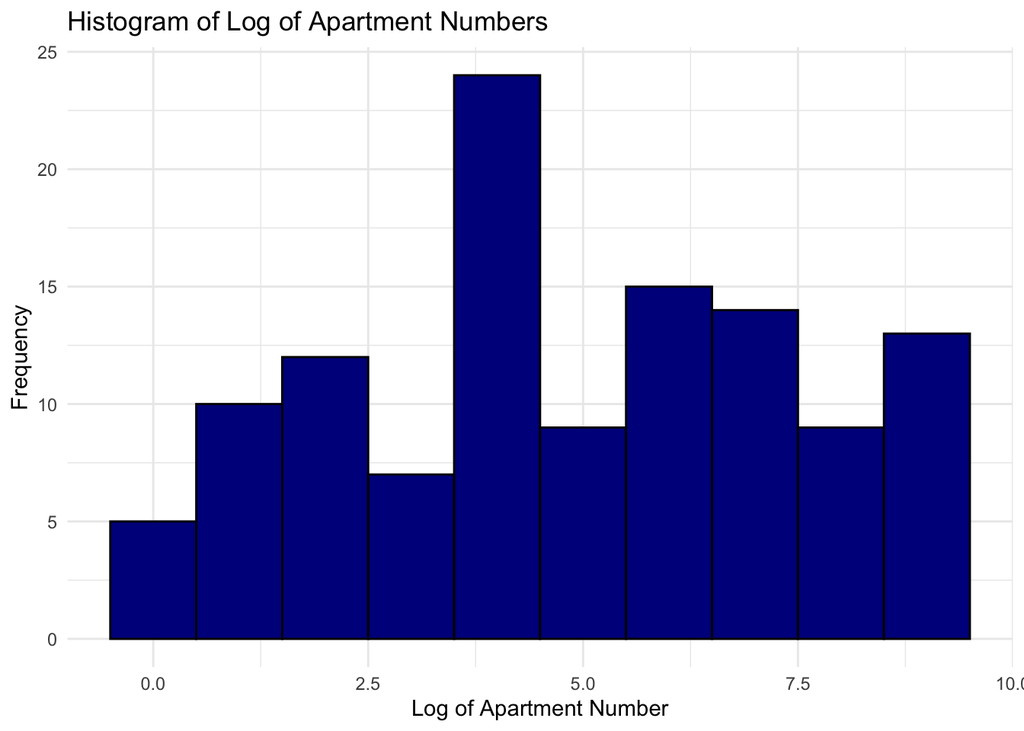

```r
library(ggplot2)

# Replace all words before numbers
us_500_apt <- us_500 %>%
  mutate(apt = as.numeric(sub(".*[^0-9]([0-9]+)$", "\\1", address)))
# Filter NAs in APT numbers
apt <- us_500_apt %>%
  filter(!is.na(apt))

# Create the histogram
ggplot(apt, aes(x = log(apt))) +
  geom_histogram(binwidth = 1, fill = "darkblue", color = "black") +
  labs(title = "Histogram of Log of Apartment Numbers", x = "Log of Apartment Number", y = "Frequency") +
  theme_minimal()
```

### e. Benford’s law is an observation about the distribution of the leading digit of real numerical data. Examine whether the apartment numbers appear to follow Benford’s law. Do you think the apartment numbers would pass as real data?

I don’t think the apartment numbers would pass as real data as the distribution of their leading digits don’t follow Benford’s law, given the *p*-value of chi-square test is less than 0.05.

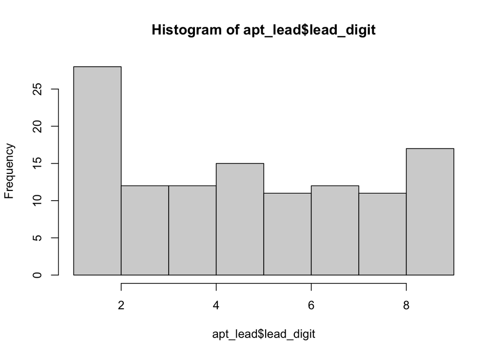

```r
# Extract all leading digits in the apt number produced in the last question
apt_lead <- apt %>%
  mutate(lead_digit = as.numeric(substring(apt, 1, 1)))
hist(apt_lead$lead_digit)
```

```r
# A table for the frequency
apt_proportions <- data.frame(table(apt_lead$lead_digit))
# Test the distribution against the benford's law
benford_proportions <- data.frame(
  lead_digit = 1:9,
  prop = log10(1 + 1 / (1:9))
)
chisq.test(x = apt_proportions$Freq, p = benford_proportions$prop)
```

```
    Chi-squared test for given probabilities

data:  apt_proportions$Freq
X-squared = 52.84, df = 8, p-value = 1.158e-08
```